# wearable computers

Theo Livingwell

October 26, 2017

Load required packages

```r
library(ggplot2)
library(dplyr)
library(magrittr)
```

Q1-2. Load, explore and process activity monitoring data

```r
activity_monitors <- read.csv("D:/Document/Supplement/Data_Sci/Repro_Reseach/activity.csv")
summary(activity_monitors)
```

```
##      steps              date          interval
##  Min.   :  0.00   01-10-12:  288   Min.   :   0.0
##  1st Qu.:  0.00   01-11-12:  288   1st Qu.: 588.8
##  Median :  0.00   02-10-12:  288   Median :1177.5
##  Mean   : 37.38   02-11-12:  288   Mean   :1177.5
##  3rd Qu.: 12.00   03-10-12:  288   3rd Qu.:1766.2
##  Max.   :806.00   03-11-12:  288   Max.   :2355.0
##  NA's   :2304     (Other) :15840
```

```r
names(activity_monitors)
```

```
## [1] "steps"    "date"     "interval"
```

```r
head(activity_monitors)
```

```
##   steps     date interval
## 1    NA 01-10-12        0
## 2    NA 01-10-12        5
## 3    NA 01-10-12       10
## 4    NA 01-10-12       15
## 5    NA 01-10-12       20
## 6    NA 01-10-12       25
```

```r
glimpse(activity_monitors)
```

```
## Observations: 17,568
## Variables: 3
## $ steps    <int> NA, NA, NA, NA, NA, NA, NA, NA, NA, NA, NA, NA, NA, N...
## $ date     <fctr> 01-10-12, 01-10-12, 01-10-12, 01-10-12, 01-10-12, 01...
## $ interval <int> 0, 5, 10, 15, 20, 25, 30, 35, 40, 45, 50, 55, 100, 10...
```

```r
head(activity_monitors)
```

```
##   steps     date interval
## 1    NA 01-10-12        0
## 2    NA 01-10-12        5
## 3    NA 01-10-12       10
## 4    NA 01-10-12       15
## 5    NA 01-10-12       20
## 6    NA 01-10-12       25
```

```r
activity_monitors$date <- as.Date(activity_monitors$date)
```

What is the mean total number of steps taken per day?

Q1. Calculate the total number of steps taken per day

```r
sum_daily_steps <- activity_monitors %>%
  group_by(date) %>%
  filter(!is.na(steps)) %>%
  summarise(total_daily_steps= sum(steps, na.rm=TRUE))
sum_daily_steps
```

```
## # A tibble: 53 × 2
##          date total_daily_steps
##        <date>             <int>
## 1  0002-10-12               126
## 2  0002-11-12             10600
## 3  0003-10-12             11352
## 4  0003-11-12             10571
## 5  0004-10-12             12116
## 6  0005-10-12             13294
## 7  0005-11-12             10439
## 8  0006-10-12             15420
## 9  0006-11-12              8334
## 10 0007-10-12             11015
## # ... with 43 more rows
```

Q2. Histogram of total daily steps

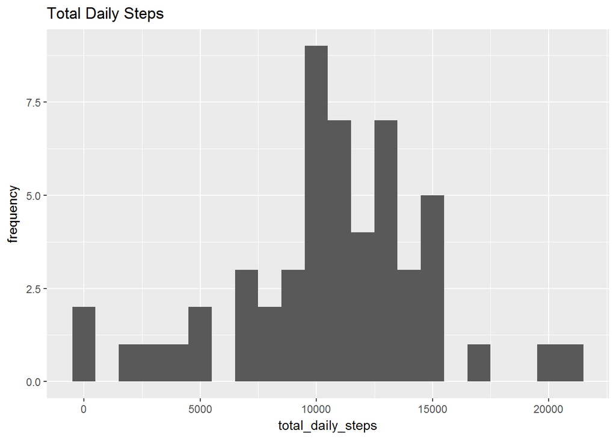

```r
ggplot(sum_daily_steps, aes(x=total_daily_steps)) + geom_histogram(
  fil="red", binwidth = 1000
) + labs(title = "Total Daily Steps", x="total_daily_steps", y="frequency")
```

Q3. Calculate and report the mean and median of the total number of steps taken per day

```r
mean_daily_steps <- mean(sum_daily_steps$total_daily_steps)

mean_daily_steps
```

```
## [1] 10766.19
```

```r
median_daily_steps <- median(sum_daily_steps$total_daily_steps, na.rm = TRUE)

median_daily_steps
```

```
## [1] 10765
```

What is the average daily activity pattern?

Q1. workout average daily steps

```r
gaps <- activity_monitors%>%
  group_by (interval)%>%
  filter(!is.na(steps))%>%
  summarise(average_steps = mean(steps, na.rm=TRUE))
gaps
```

```
## # A tibble: 288 × 2
##    interval average_steps
##       <int>         <dbl>
## 1         0     1.7169811
## 2         5     0.3396226
## 3        10     0.1320755
## 4        15     0.1509434
## 5        20     0.0754717
## 6        25     2.0943396
## 7        30     0.5283019
## 8        35     0.8679245
## 9        40     0.0000000
## 10       45     1.4716981
## # ... with 278 more rows
```

Cretaing a time series plot of 5 minutes interval

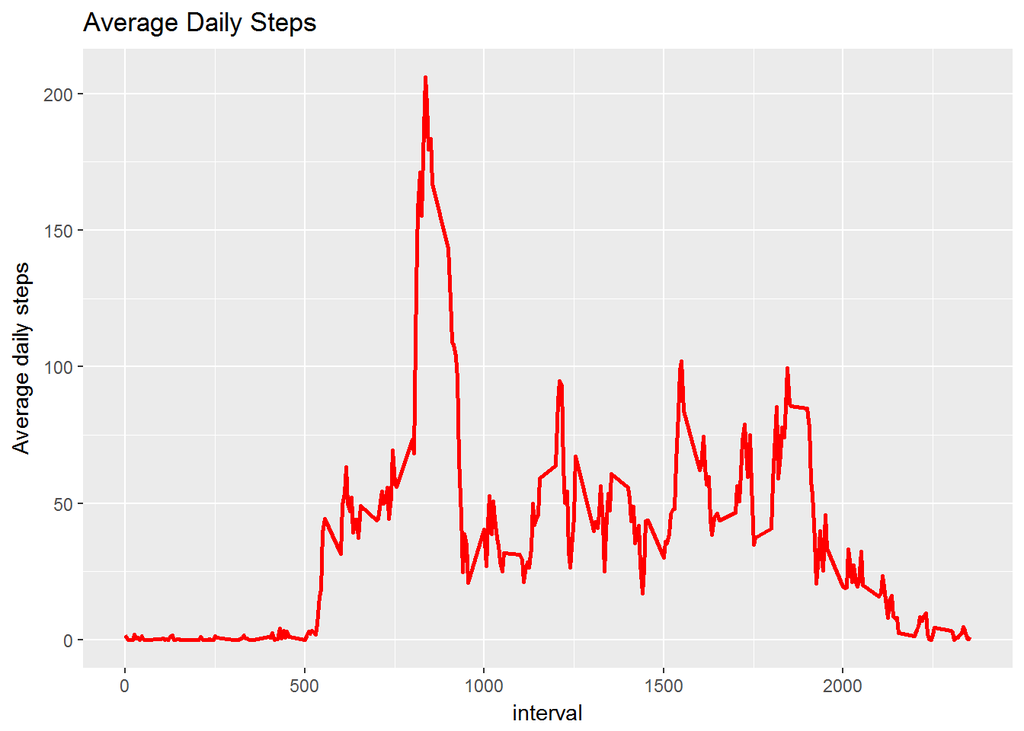

```r
ggplot(gaps, aes(x=interval, y=average_steps)) +
  geom_line(color="red", size=1) +
  labs(title= "Average Daily Steps", x="interval", y= "Average daily steps")
```

Q2. Which 5-minute interval, on average across all the days in the dataset, contains the maximum number of steps?

```r
gaps[which.max(gaps$average_steps), ]
```

```
## # A tibble: 1 × 2
##   interval average_steps
##      <int>         <dbl>
## 1      835      206.1698
```

Interval 835 contains 206.1698 average step which is the maximum

Imputing missing values

Q1. Calculate and report the total number of missing values in the dataset (i.e. the total number of rows with NAs)

```r
sum(is.na(activity_monitors$steps))
```

```
## [1] 2304
```

```r
activity_monitors_fill <-activity_monitors
missingValues <- is.na(activity_monitors_fill$steps)
averageInterval <- tapply(activity_monitors_fill$steps, activity_monitors_fill$interval, mean, na.rm=TRUE, simplify = TRUE)
activity_monitors_fill$steps[missingValues] <- averageInterval[as.character(activity_monitors_fill$interval[missingValues])]
names(activity_monitors_fill)
```

```
## [1] "steps"    "date"     "interval"
```

```r
sum(is.na(activity_monitors_fill))      # checking for missing Values, NAs
```

```
## [1] 0
```

Reorganise table for better presentation

```r
activity_monitors_fill <- activity_monitors_fill[, c("date", "steps", "interval")]
head(activity_monitors_fill, 5)
```

```
##         date     steps interval
## 1 0001-10-12 1.7169811        0
## 2 0001-10-12 0.3396226        5
## 3 0001-10-12 0.1320755       10
## 4 0001-10-12 0.1509434       15
## 5 0001-10-12 0.0754717       20
```

Q4. Make a histogram of the total number of steps taken each day and Calculate and report the mean and median total number of steps taken per day. Do these values differ from the estimates from the first part of the assignment? What is the impact of imputing missing data on the estimates of the total daily number of steps?

```r
total_daily_steps <- activity_monitors_fill%>%
  group_by(date)%>%
  summarise(total_step =  sum(steps, na.rm=TRUE))
total_daily_steps
```

```
## # A tibble: 61 × 2
##          date total_step
##        <date>      <dbl>
## 1  0001-10-12   10766.19
## 2  0001-11-12   10766.19
## 3  0002-10-12     126.00
## 4  0002-11-12   10600.00
## 5  0003-10-12   11352.00
## 6  0003-11-12   10571.00
## 7  0004-10-12   12116.00
## 8  0004-11-12   10766.19
## 9  0005-10-12   13294.00
## 10 0005-11-12   10439.00
## # ... with 51 more rows
```

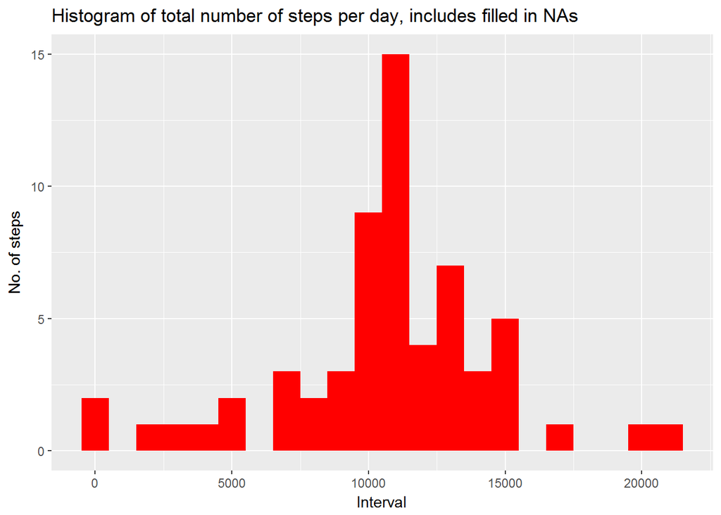

```r
ggplot(total_daily_steps, aes(x=total_step)) + geom_histogram(fill="red", binwidth = 1000) +
  labs(title = "Histogram of total number of steps per day, includes filled in NAs",  x = "Interval",
       y = "No. of steps")
```

```r
mean_daily_steps2 <- mean(total_daily_steps$total_step, na.rm = TRUE)
mean_daily_steps2
```

```
## [1] 10766.19
```

```r
median_daily_steps2 <- median(total_daily_steps$total_step, na.rm = TRUE)
median_daily_steps2
```

```
## [1] 10766.19
```

The mean and median are both the same (10766.19) with all the NAs filled in

Are there differences in activity patterns between weekdays and weekends?

Q1. Create a new factor variable in the dataset with two levels - “weekday” and “weekend” indicating whether a given date is a weekday or weekend day.

```r
head(activity_monitors_fill)
```

```
##         date     steps interval
## 1 0001-10-12 1.7169811        0
## 2 0001-10-12 0.3396226        5
## 3 0001-10-12 0.1320755       10
## 4 0001-10-12 0.1509434       15
## 5 0001-10-12 0.0754717       20
## 6 0001-10-12 2.0943396       25
```

```r
activity_monitors_fill <- activity_monitors_fill %>%
  mutate(weektype = ifelse(weekdays(activity_monitors_fill$date) == "saturday" | weekdays(activity_monitors_fill$date) == "sunday", "weekend", "weekday"))
head(activity_monitors_fill)
```

```
##         date     steps interval weektype
## 1 0001-10-12 1.7169811        0  weekday
## 2 0001-10-12 0.3396226        5  weekday
## 3 0001-10-12 0.1320755       10  weekday
## 4 0001-10-12 0.1509434       15  weekday
## 5 0001-10-12 0.0754717       20  weekday
## 6 0001-10-12 2.0943396       25  weekday
```

```r
interval_df<- activity_monitors_fill %>%
  group_by(interval, weektype) %>%
  summarise(average_step2 = mean(steps, na.rm=TRUE))

head(interval_df)
```

```
## Source: local data frame [6 x 3]
## Groups: interval [6]
##
##   interval weektype average_step2
##      <int>    <chr>         <dbl>
## 1        0  weekday     1.7169811
## 2        5  weekday     0.3396226
## 3       10  weekday     0.1320755
## 4       15  weekday     0.1509434
## 5       20  weekday     0.0754717
## 6       25  weekday     2.0943396
```

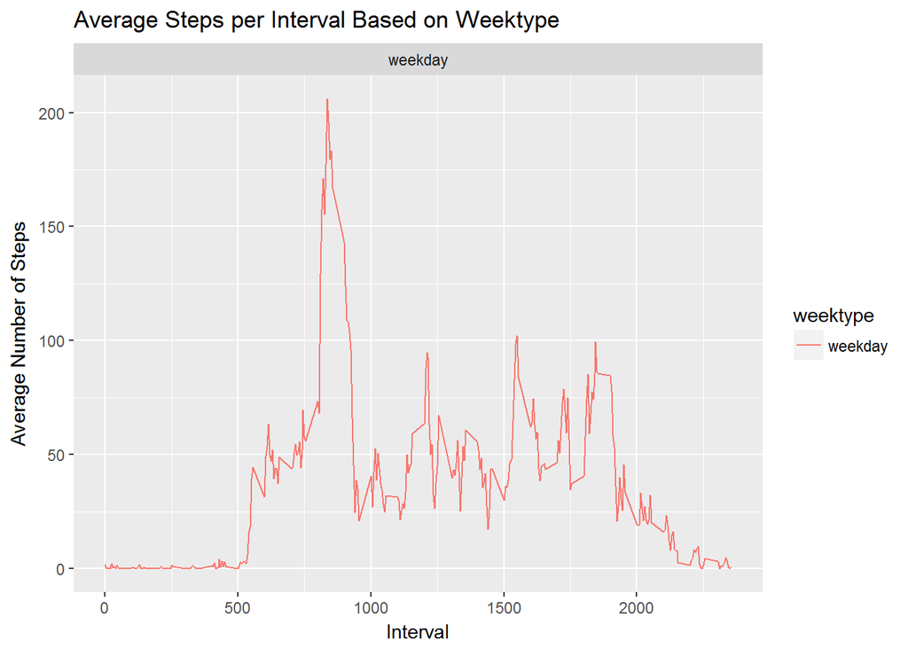

```r
graph <- ggplot(interval_df, aes(x=interval, y=average_step2, color = weektype)) +

  geom_line() +
  labs(title = "Average Steps per Interval Based on Weektype", x = "Interval", y = "Average Number of Steps") +
  facet_wrap(~weektype, ncol = 1, nrow = 2)

print(graph)
```